# Machine Learning-I (CS/DS 706)-Assignment 1

Question 1 a.

Step1: Load the Salary.csv dataset

```python
import pandas as pd
import numpy as np
import random
import math
import statistics as s
import matplotlib.pyplot as plt
```

```python
salary = pd.read_csv(r'/home/kanika/Downloads/Salaries.csv')
```

```python
salary = salary[['Id','TotalPay']]
```

```python
#Displaying top 5 rows
salary[:5]
```

|  | Id | TotalPay |
| --- | --- | --- |
| 0 | 1 | 567595.43 |
| 1 | 2 | 538909.28 |
| 2 | 3 | 335279.91 |
| 3 | 4 | 332343.61 |
| 4 | 5 | 326373.19 |

Step2: Calculate the Aggregate function on the entire column 'Total Pay'. The Agggregate function we picked is **mean**

```python
mean = salary['TotalPay'].mean()
print("Mean of the entire column 'TotalPay' = ",mean)
```

```
Mean of the entire column 'TotalPay' =  74768.3219717
```

Step 3 Pick a fraction in the range ρ ∈ (0, 1) : Let ρ =0.6

```python
p=0.6
n= int(salary.shape[0])
np= n*p
np
```

```
89192.4
```

Step 4 Randomly (uniform) sample nρ elements from the dataset:

```python
#Done ceil to get rounded number of rows
np=math.ceil(np)
#using sample function to generate the random number of rows
sample =random.sample(range(n), int(np))
```

```python
# to select the values of the column 'TotalPay' respective to the row numbered sampled above
sampleTotalPay = salary[salary['Id'].isin(sample)]
sampleTotalPay = sampleTotalPay['TotalPay']
```

Step5 Compute the sample statistic τci:

```python
sample_mean =sampleTotalPay.mean()
print("Mean of the sampled data is = ",sample_mean)
```

```
Mean of the sampled data is =  74643.467479
```

Step6 Repeating step 5 m times :  
Let m= 100

```python
sampled_mean_vector = []
for i in range(100):
    sample =random.sample(range(n), int(np))
    sampleTotalPay = salary[salary['Id'].isin(sample)]
    sampleTotalPay = sampleTotalPay['TotalPay']
    sample_mean =float(sampleTotalPay.mean())
    sampled_mean_vector.append(sample_mean)
print("List of m means is as follows \n",sampled_mean_vector    )
```

[output not shown]

Step 7 Calculating the average mean:

```python
average_mean =s.mean(sampled_mean_vector)
print("Average Mean = ", average_mean)
```

```
Average Mean =  74760.91034136011
```

```python
p_vector = np.arange(0.01,1.01,0.01)
p_vector
```

```
array([ 0.01,  0.02,  0.03,  0.04,  0.05,  0.06,  0.07,  0.08,  0.09,
        0.1 ,  0.11,  0.12,  0.13,  0.14,  0.15,  0.16,  0.17,  0.18,
        0.19,  0.2 ,  0.21,  0.22,  0.23,  0.24,  0.25,  0.26,  0.27,
        0.28,  0.29,  0.3 ,  0.31,  0.32,  0.33,  0.34,  0.35,  0.36,
        0.37,  0.38,  0.39,  0.4 ,  0.41,  0.42,  0.43,  0.44,  0.45,
        0.46,  0.47,  0.48,  0.49,  0.5 ,  0.51,  0.52,  0.53,  0.54,
        0.55,  0.56,  0.57,  0.58,  0.59,  0.6 ,  0.61,  0.62,  0.63,
        0.64,  0.65,  0.66,  0.67,  0.68,  0.69,  0.7 ,  0.71,  0.72,
        0.73,  0.74,  0.75,  0.76,  0.77,  0.78,  0.79,  0.8 ,  0.81,
        0.82,  0.83,  0.84,  0.85,  0.86,  0.87,  0.88,  0.89,  0.9 ,
        0.91,  0.92,  0.93,  0.94,  0.95,  0.96,  0.97,  0.98,  0.99,  1.  ])
```

```python
# y is the list which will store the average mean of the different values of p
y = []
for p in p_vector:
    np=n*p
    sampled_mean_vector=[]
    for i in range(100):
        sample =random.sample(range(n), int(np))
        sampleTotalPay = salary[salary['Id'].isin(sample)]
        sampleTotalPay = sampleTotalPay['TotalPay']
        sample_mean =float(sampleTotalPay.mean())
        sampled_mean_vector.append(sample_mean)
        mean= float(s.mean(sampled_mean_vector))
    y.append(mean)

y
```

```
[74670.84214367384,
 74729.9949381508,
 74686.6858851116,
 74697.91787154487,
 74695.28067743032,
 74825.00977167232,
 74658.75429762345,
 74735.27952505839,
 74686.49954291353,
 74766.12618001566,
 74798.61345184923,
 74721.00205714298,
 74792.74423616914,
 74765.07465742365,
 74801.43197021319,
 74768.88763005339,
 74758.09859011651,
 74705.93284051889,
 74820.66558571332,
 74763.16738746157,
 74729.2161505441,
 74818.43124713241,
 74809.61133759358,
 74776.4047833415,
 74787.06200935027,
 74761.8780721295,
 74753.7684960161,
 74749.38574381384,
 74764.90752868778,
 74759.53116618331,
 74759.94051706402,
 74772.61678808616,
 74747.44480566728,
 74784.42355308903,
 74757.16421589346,
 74770.02311759426,
 74776.47527793313,
 74763.34278695344,
 74750.96922571267,
 74730.70507037712,
```

[output cut: 45 more lines]

```
 74770.57135003973,
 74774.99118164057,
 74762.92230966325,
 74771.02968130457,
 74775.81242878003,
 74767.28763156255,
 74764.42253956883,
 74772.46426096983,
 74769.48085502847,
 74771.80192867537,
 74770.00198968717,
 74770.38161411199,
 74767.78431827546,
 74770.1503323322,
 74768.82910206994]
```

Now to plot the values we used the plot function on the y-axis the average mean values are plotted and x-axis the p values.

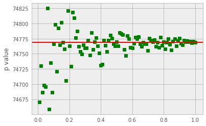

```python
plt.plot(p_vector,y,'gs')
plt.axhline(y=mean, xmin=0, xmax=1,lw=2,c="red")
plt.ylabel('Average Mean Value')
plt.ylabel('p value')
plt.show()
```

Observation:

As the value of p increases and gets close to 1, the value of the average mean from the m iterations of experiment generated gets close to value of the mean of the entire column ‘TotalPay’ also .